# CIND 123 - Data Analytics: Basic Methods Winter2021 Assignment 3

# Assignment 3 (10%)

## Instructions

Use RStudio for this assignment. Complete the assignment by inserting your R code wherever you see the string “#INSERT YOUR ANSWER HERE”.

Submit **both** the rmd and generated output files. Failing to submit both files will be subject to mark deduction.

## Sample Question and Solution

Use `seq()` to create the vector $(2,4,6,\ldots,20)$.

```r
#Insert your code here.
seq(2,20,by = 2)
```

```
##  [1]  2  4  6  8 10 12 14 16 18 20
```

### Note:

You will use ‘Admission_Predict.csv’ for Assignment-3. This dataset includes the data of the applicants of an academic program. Each application has a unique serial number, which represents a particular student. The dataset contains several parameters which are considered important during the application for Masters Programs. The parameters included are :

1. GRE Scores (out of 340)
2. TOEFL Scores (out of 120)
3. University Rating (out of 5)
4. Statement of Purpose (SOP) (out of 5)
5. Letter of Recommendation (LOR) Strength (out of 5)
6. Undergraduate GPA (out of 10)
7. Research Experience (either 0 or 1)
8. Chance of Admit (ranging from 0 to 1)

**Download “Admission_Predict.csv” dataset and load it as ‘data’.**

```r
Admission_DataSet <- read.csv(file="Admission_Predict.csv", header= T)
```

## Question 1 (30 points in total)

1. i- Display the first three rows in this dataset.(1 point)

```r
head(Admission_DataSet,3)
```

```
##   Serial.No. GRE.Score TOEFL.Score University.Rating SOP LOR CGPA Research
## 1          1       337         118                 4 4.5 4.5 9.65        1
## 2          2       324         107                 4 4.0 4.5 8.87        1
## 3          3       316         104                 3 3.0 3.5 8.00        1
##   Chance.of.Admit
## 1            0.92
## 2            0.76
## 3            0.72
```

ii - Display the structure of all variables.(1 point)

```r
str(Admission_DataSet)
```

```
## 'data.frame':    400 obs. of  9 variables:
##  $ Serial.No.       : int  1 2 3 4 5 6 7 8 9 10 ...
##  $ GRE.Score        : int  337 324 316 322 314 330 321 308 302 323 ...
##  $ TOEFL.Score      : int  118 107 104 110 103 115 109 101 102 108 ...
##  $ University.Rating: int  4 4 3 3 2 5 3 2 1 3 ...
##  $ SOP              : num  4.5 4 3 3.5 2 4.5 3 3 2 3.5 ...
##  $ LOR              : num  4.5 4.5 3.5 2.5 3 3 4 4 1.5 3 ...
##  $ CGPA             : num  9.65 8.87 8 8.67 8.21 9.34 8.2 7.9 8 8.6 ...
##  $ Research         : int  1 1 1 1 0 1 1 0 0 0 ...
##  $ Chance.of.Admit  : num  0.92 0.76 0.72 0.8 0.65 0.9 0.75 0.68 0.5 0.45 ...
```

iii - Print the descriptive statistics of the admission data to understand the data a little better (min, max, mean, median, 1st and 3rd quartiles). (1 point)

```r
summary(Admission_DataSet)
```

```
##    Serial.No.      GRE.Score      TOEFL.Score    University.Rating
##  Min.   :  1.0   Min.   :290.0   Min.   : 92.0   Min.   :1.000
##  1st Qu.:100.8   1st Qu.:308.0   1st Qu.:103.0   1st Qu.:2.000
##  Median :200.5   Median :317.0   Median :107.0   Median :3.000
##  Mean   :200.5   Mean   :316.8   Mean   :107.4   Mean   :3.087
##  3rd Qu.:300.2   3rd Qu.:325.0   3rd Qu.:112.0   3rd Qu.:4.000
##  Max.   :400.0   Max.   :340.0   Max.   :120.0   Max.   :5.000
##       SOP           LOR             CGPA          Research
##  Min.   :1.0   Min.   :1.000   Min.   :6.800   Min.   :0.0000
##  1st Qu.:2.5   1st Qu.:3.000   1st Qu.:8.170   1st Qu.:0.0000
##  Median :3.5   Median :3.500   Median :8.610   Median :1.0000
##  Mean   :3.4   Mean   :3.453   Mean   :8.599   Mean   :0.5475
##  3rd Qu.:4.0   3rd Qu.:4.000   3rd Qu.:9.062   3rd Qu.:1.0000
##  Max.   :5.0   Max.   :5.000   Max.   :9.920   Max.   :1.0000
##  Chance.of.Admit
##  Min.   :0.3400
##  1st Qu.:0.6400
##  Median :0.7300
##  Mean   :0.7244
##  3rd Qu.:0.8300
##  Max.   :0.9700
```

iv - Use a histogram to assess the normality of the ‘Chance.of.Admit’ variable and explain whether it appears normally distributed or not and why? (1 point)

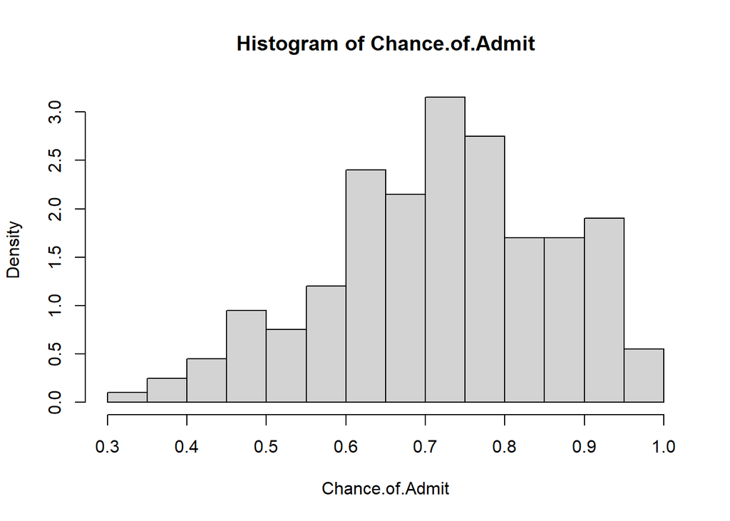

```r
Chance.of.Admit <- Admission_DataSet$Chance.of.Admit
hist(Chance.of.Admit, probability= T )
```

```r
# The histogram sounds symmetric and it has density around the mean of Chance of Admit(0.7244) but it is a little skewed to the left because the median (0.7300) is a little bit greater than Mean(0.7244).
```

2. Create a set of boxplots that shows the distribution of Chance.of.Admit and SOP variables.Use different colors for different SOP scores month. (8 points)

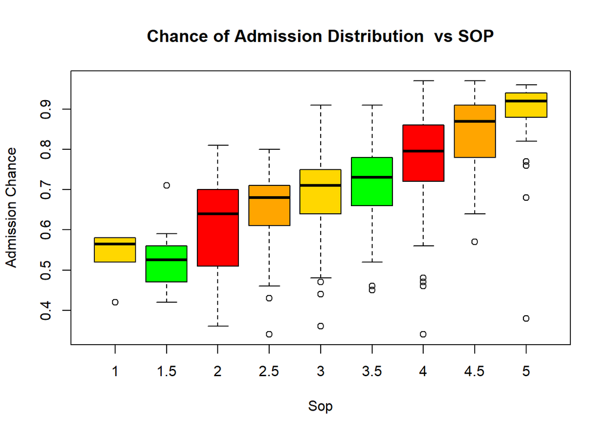

```r
Sop <- Admission_DataSet$SOP

boxplot(Chance.of.Admit ~ Sop , data=Admission_DataSet , xlab ="Sop" ,ylab = "Admission Chance"  ,
        col=(c("gold","green","red","orange")),
        main="Chance of Admission Distribution  vs SOP")
```

i- Find the covariance between the “GRE.Score” and the “Chance.of.Admit”. (3 points)

```r
# The value of the covariance is about 1.31 that indicate positive linear relationship between these two variables.

cov(Admission_DataSet$GRE.Score,Admission_DataSet$Chance.of.Admit)
```

```
## [1] 1.313271
```

```r
# This is a extra step

cov(Admission_DataSet$TOEFL.Score,Admission_DataSet$Chance.of.Admit)
```

```
## [1] 0.6851794
```

```r
cov(Admission_DataSet$CGPA,Admission_DataSet$Chance.of.Admit)
```

```
## [1] 0.07426484
```

ii- Find the correlation between the “GRE.Score”, “TOEFL.Score”, “CGPA” and the “Chance.of.Admit”. (3 points)

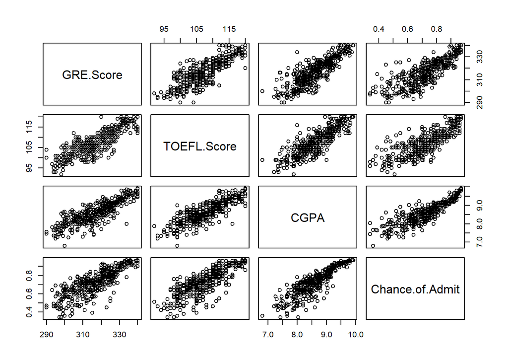

```r
# I use pair() function to create a scatter plot matrix for the following variables.It is just extra step.

vars <- c("GRE.Score","TOEFL.Score","CGPA","Chance.of.Admit" )
pairs(Admission_DataSet[vars])
```

```r
Mydata <- Admission_DataSet[,c(2,3,7,9)]


cor(Mydata)
```

```
##                 GRE.Score TOEFL.Score      CGPA Chance.of.Admit
## GRE.Score       1.0000000   0.8359768 0.8330605       0.8026105
## TOEFL.Score     0.8359768   1.0000000 0.8284174       0.7915940
## CGPA            0.8330605   0.8284174 1.0000000       0.8732891
## Chance.of.Admit 0.8026105   0.7915940 0.8732891       1.0000000
```

iii - Interpret the covariance and correlation results obtained from i and ii in terms of the strength and direction of the relationship. (4 points)

```r
# The value of the covariance and correlation for GRE.Score  are  1.3132 and 0.8026 respectively that indicates strong positive linear relationship between two variables. The value of the covariance and correlation for TOEFL.Score  are  0.6851 and 0.7915 respectively that indicates relatively strong positive linear relationship between two variables. The value of the covariance and correlation for CGPA  are  0.0742 and 0.8732 respectively that indicates very strong positive linear relationship between these two variables.(These Relationship are shown well in the Pairs() and ggplot()diagram)
```

4. Use ggplot() to plot the graphs to see the relationship between each of three variables (GRE.Score, TOEFL.Score, CGPA) with Chance.of.Admit. (8 points)

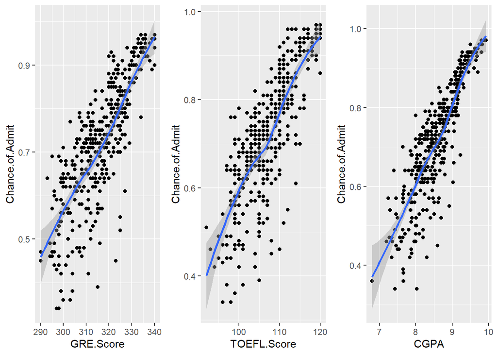

```r
library(ggplot2)
require(gridExtra)
#install.packages("gridExtra")

GRE.Score <-Admission_DataSet$GRE.Score
TOEFL.Score <-Admission_DataSet$TOEFL.Score
CGPA <- Admission_DataSet$CGPA



GREggplot <- ggplot(Admission_DataSet,aes(x=GRE.Score , y= Chance.of.Admit))+
  geom_point()+
  stat_smooth()

TOEFLggplot<- ggplot(Admission_DataSet,aes(x=TOEFL.Score , y= Chance.of.Admit))+
  geom_point()+
  stat_smooth()

CGPAggplot <- ggplot(Admission_DataSet,aes(x=CGPA , y= Chance.of.Admit))+
  geom_point()+
  stat_smooth()


grid.arrange(GREggplot,TOEFLggplot, CGPAggplot , nrow= 1 , ncol=3)
```